# Airplane Data Report

Jimin Lee

2025-03-16

## Import

```r
library(tidyverse)
library(forecast)
library(tseries)
```

### 기초 통계량 분석

```r
summary(AirPassengers)
```

```
##    Min. 1st Qu.  Median    Mean 3rd Qu.    Max.
##   104.0   180.0   265.5   280.3   360.5   622.0
```

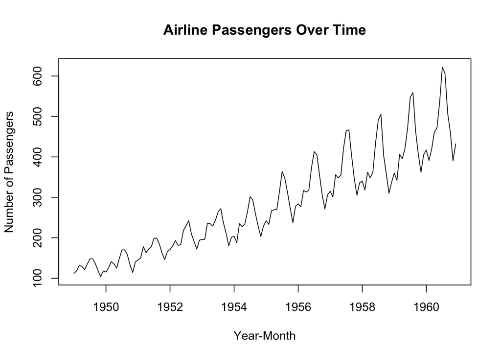

```r
plot(AirPassengers, main = "Airline Passengers Over Time",
     xlab = "Year-Month", ylab = "Number of Passengers")
```

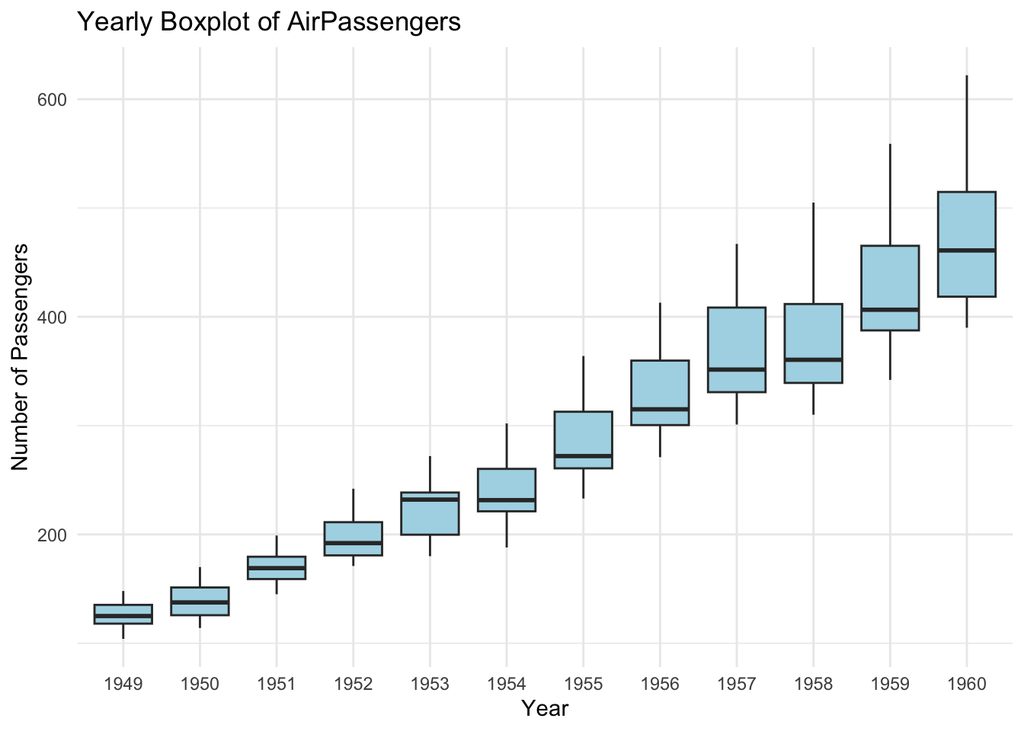

```r
# 데이터프레임으로 변환
df <- data.frame(
  year = floor(time(AirPassengers)),  # 연도 추출
  month = cycle(AirPassengers),  # 월 추출
  passengers = as.numeric(AirPassengers)  # 승객 수
)

# 연도별 박스플롯 생성
ggplot(df, aes(x = factor(year), y = passengers)) +
  geom_boxplot(fill = "lightblue") +
  labs(title = "Yearly Boxplot of AirPassengers",
       x = "Year",
       y = "Number of Passengers") +
  theme_minimal()
```

1949년부터 1960년까지의 베행기 탑승객 수는 강한 계절성을 띄며, 양의 추세를 보인다.

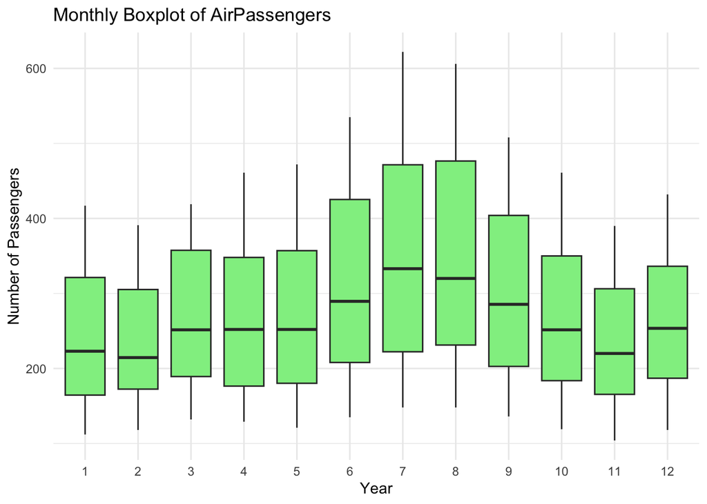

```r
# 연도별 박스플롯 생성
ggplot(df, aes(x = factor(month), y = passengers)) +
  geom_boxplot(fill = "lightgreen") +
  labs(title = "Monthly Boxplot of AirPassengers",
       x = "Year",
       y = "Number of Passengers") +
  theme_minimal()
```

2월과 11월에 비행기 탑승객의 수가 가장 적었으며, 6-8(여름)기간에는 탑승객의 수가 많았다.

## 시계열 분해

### naive

- 가법 모델

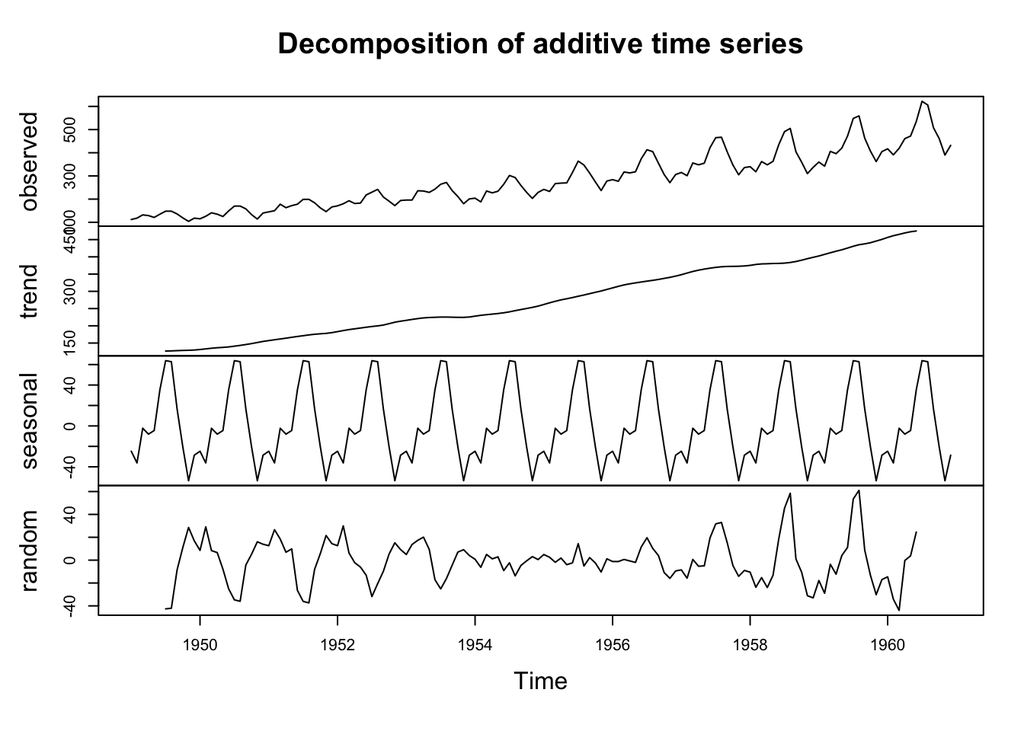

```r
# Decompose the time series
decomposed_additive = decompose(AirPassengers, type="additive")

plot(decomposed_additive)
```

```r
random_component <- na.omit(decomposed_additive$random)  # NA 제거

shapiro.test(random_component)  # 정규성 검정
```

```
##
##  Shapiro-Wilk normality test
##
## data:  random_component
## W = 0.97502, p-value = 0.0155
```

```r
# ADF (Augmented Dickey-Fuller) Test:
# 귀무가설(H0) → 비정상 시계열 ; 대립가설(H1) → 정상 시계열
adf_result <- adf.test(random_component)
cat("📌 ADF 검정 결과:\n")
```

```
## 📌 ADF 검정 결과:
```

```r
print(adf_result)
```

```
##
##  Augmented Dickey-Fuller Test
##
## data:  random_component
## Dickey-Fuller = -9.3579, Lag order = 5, p-value = 0.01
## alternative hypothesis: stationary
```

- 승법 모델

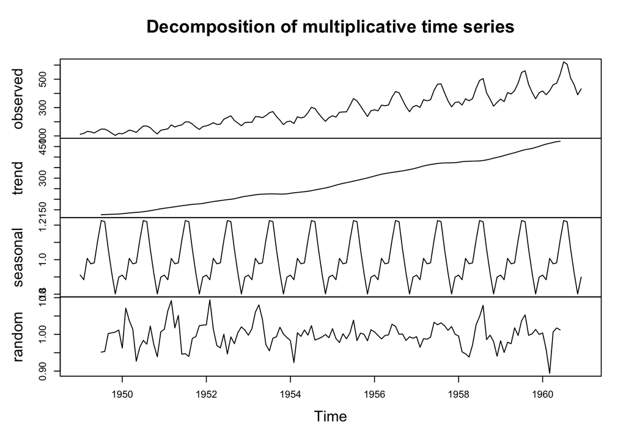

```r
decomposed_multiplicative = decompose(AirPassengers, type="multiplicative")

plot(decomposed_multiplicative)
```

### STL

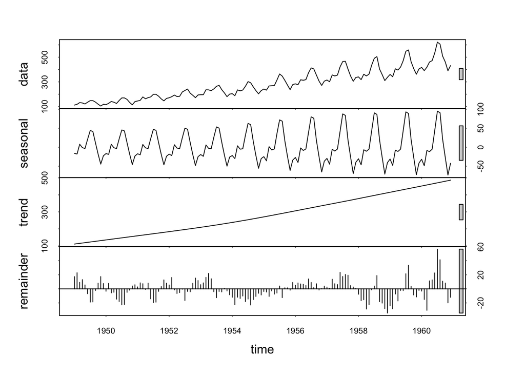

```r
plot(stl(AirPassengers, s.window = 12, t.window = 80, t.jump = 5))
```

- log를 취해 승법 모델을 가법 모델로 변환함.

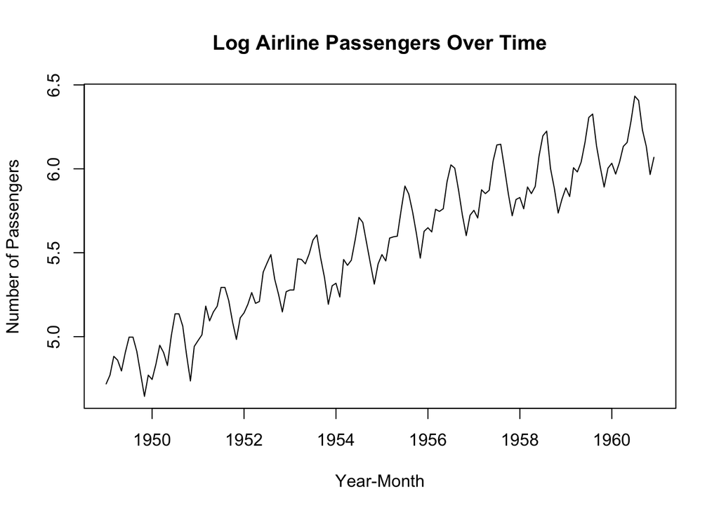

```r
plot(log(AirPassengers), main = "Log Airline Passengers Over Time",
     xlab = "Year-Month", ylab = "Number of Passengers")
```

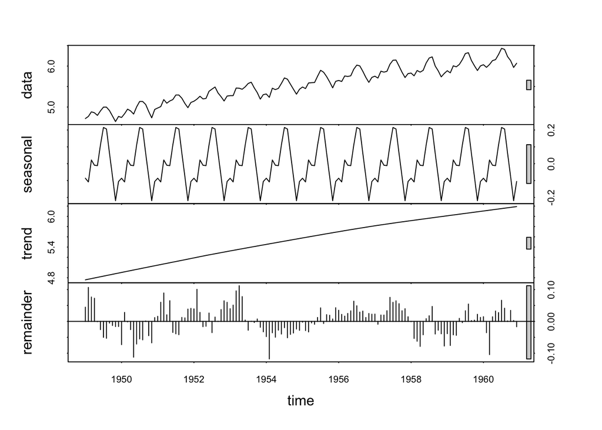

```r
stl_result <- stl(log(AirPassengers), s.window = "periodic", t.window = 80)
plot(stl_result)
```

## MA(이동평균) 평활화

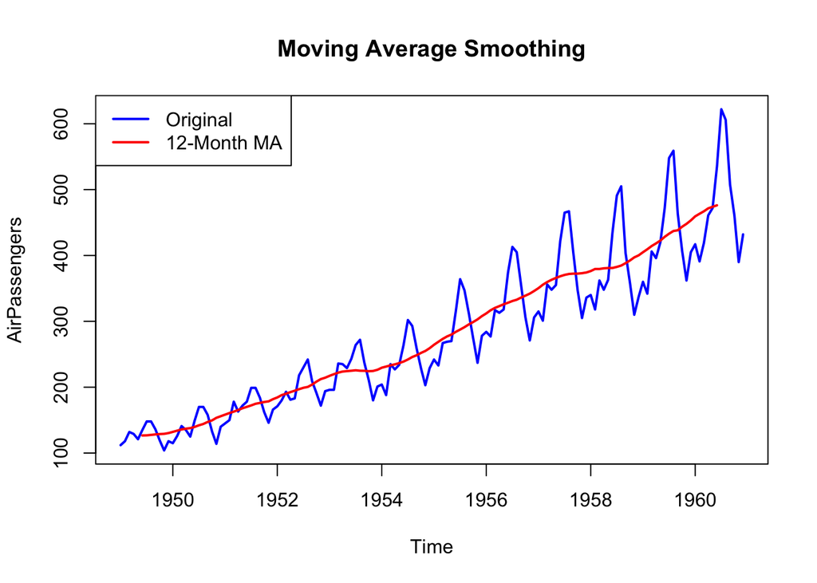

```r
moving_avg <- stats::filter(AirPassengers, rep(1/12, 12), sides = 2)
plot(AirPassengers, main = "Moving Average Smoothing", col = "blue", lwd = 2)
lines(moving_avg, col = "red", lwd = 2)
legend("topleft", legend = c("Original", "12-Month MA"), col = c("blue", "red"), lwd = 2)
```

## 모델

### 데이터 나누기

```r
ts_data <- AirPassengers

# 훈련(train) 데이터: 1949년 ~ 1959년 (총 132개 중 120개 사용)
train_data <- window(ts_data, end = c(1959, 12))

# 테스트(test) 데이터: 1960년 (마지막 12개월 예측 평가)
test_data <- window(ts_data, start = c(1960, 1))
```

### PACF 시각화

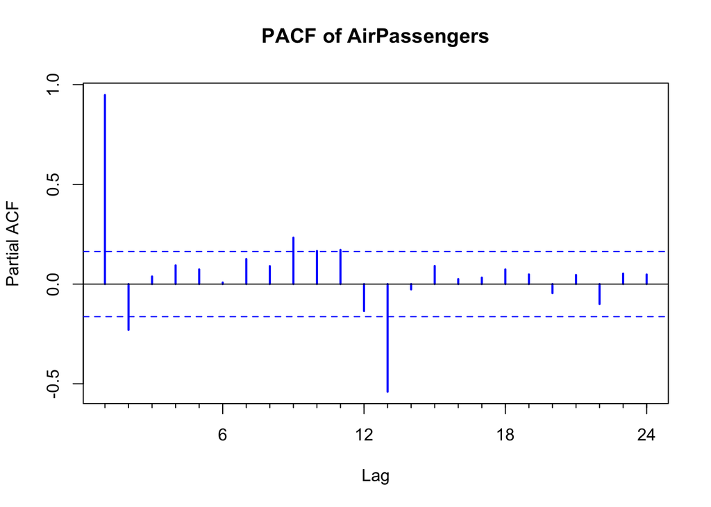

```r
Pacf(AirPassengers, main = "PACF of AirPassengers", col = "blue", lwd = 2)
```

13일때 PACF 값이 크기 때문에, AR(13) 적절

### AR (자가회귀)모델

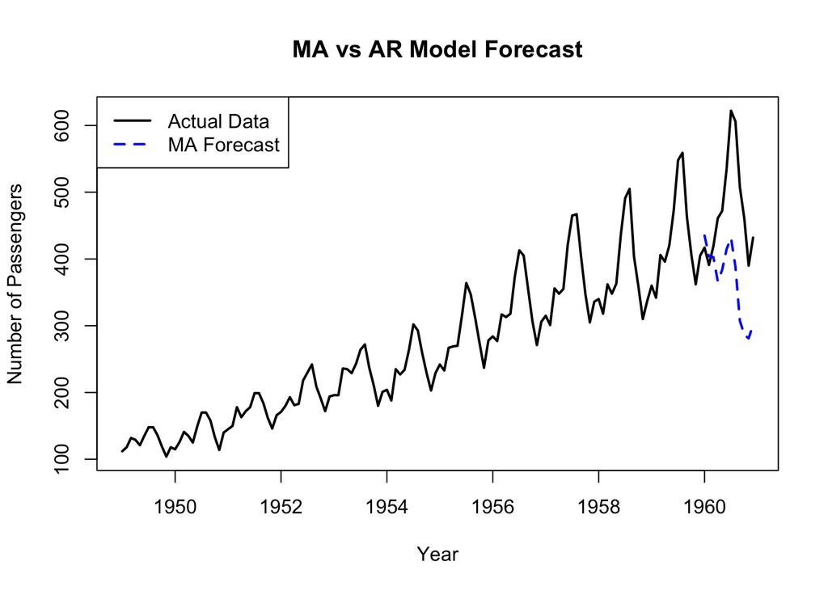

```r
#  MA (Moving Average) 모델
ma_model <- arima(train_data, order = c(0, 0, 13))  # MA(1) 모델
ma_forecast <- forecast(ma_model, h = 12)

# 시각화: 전체 데이터 포함
plot(ts_data, type = "l", col = "black", lwd = 2, ylim = range(ts_data, ma_forecast$mean),
     main = "MA vs AR Model Forecast",
     xlab = "Year", ylab = "Number of Passengers")

# MA 모델 예측값 추가
lines(ma_forecast$mean, col = "blue", lwd = 2, lty = 2)

# 범례 추가
legend("topleft",
       legend = c("Actual Data", "MA Forecast"),
       col = c("black", "blue"),
       lwd = 2, lty = c(1, 2, 2))
```

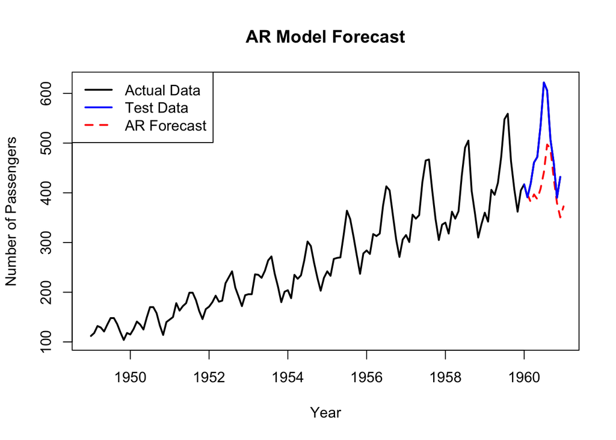

```r
ar_model <- ar(train_data)

# 3️⃣ 12개월 예측 수행
ar_pred <- predict(ar_model, n.ahead = 12)

# 4️⃣ 시각화: 전체 데이터 포함하여 예측 비교
plot(ts_data, type = "l", col = "black", lwd = 2, ylim = range(ts_data, ar_pred$pred),
     main = "AR Model Forecast",
     xlab = "Year", ylab = "Number of Passengers")

# AR 예측값 추가 (빨간 점선)
lines(1960 + (1:12)/12, ar_pred$pred, col = "red", lwd = 2, lty = 2)

# 테스트 데이터 (실제값) 추가 (파란 실선)
lines(test_data, col = "blue", lwd = 2)

# 범례 추가
legend("topleft",
       legend = c("Actual Data", "Test Data", "AR Forecast"),
       col = c("black", "blue", "red"),
       lwd = 2, lty = c(1, 1, 2))
```

### ARIMA

```r
# ARIMA 모델 적합
arima_model <- auto.arima(train_data, seasonal = FALSE)
summary(arima_model)
```

```
## Series: train_data
## ARIMA(4,1,4) with drift
##
## Coefficients:
##           ar1     ar2      ar3      ar4      ma1      ma2     ma3     ma4
##       -0.0135  0.9666  -0.1222  -0.7775  -0.0312  -1.4888  0.0301  0.8629
## s.e.   0.0741  0.0808   0.0767   0.0732   0.0798   0.0935  0.0653  0.0693
##        drift
##       2.6567
## s.e.  0.7607
##
## sigma^2 = 519.9:  log likelihood = -594.06
## AIC=1208.13   AICc=1209.96   BIC=1236.88
##
## Training set error measures:
##                     ME    RMSE      MAE        MPE     MAPE      MASE
## Training set 0.2486546 21.9213 17.13497 -0.7003438 6.705289 0.5627247
##                    ACF1
## Training set 0.07873063
```

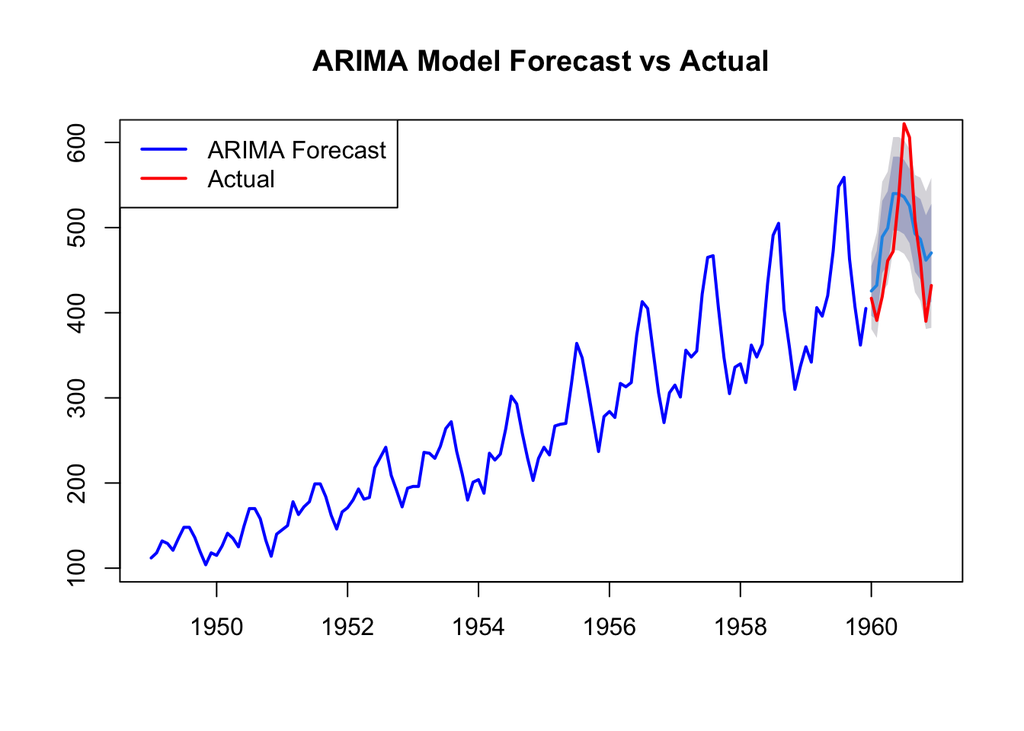

```r
# 12개월 예측 수행
arima_forecast <- forecast(arima_model, h = 12)

# 예측 결과 시각화
plot(arima_forecast, main = "ARIMA Model Forecast vs Actual", col = "blue", lwd = 2)
lines(test_data, col = "red", lwd = 2)  # 실제값 추가
legend("topleft", legend = c("ARIMA Forecast", "Actual"), col = c("blue", "red"), lwd = 2)
```

### SARIMA

```r
# 계절성 포함된 SARIMA 모델 적합
sarima_model <- auto.arima(train_data, seasonal = TRUE)
summary(sarima_model)
```

```
## Series: train_data
## ARIMA(1,1,0)(0,1,0)[12]
##
## Coefficients:
##           ar1
##       -0.2431
## s.e.   0.0894
##
## sigma^2 = 109.8:  log likelihood = -447.95
## AIC=899.9   AICc=900.01   BIC=905.46
##
## Training set error measures:
##                    ME     RMSE      MAE       MPE     MAPE      MASE       ACF1
## Training set 0.579486 9.907267 7.483159 0.1187348 2.880429 0.2457523 0.01227544
```

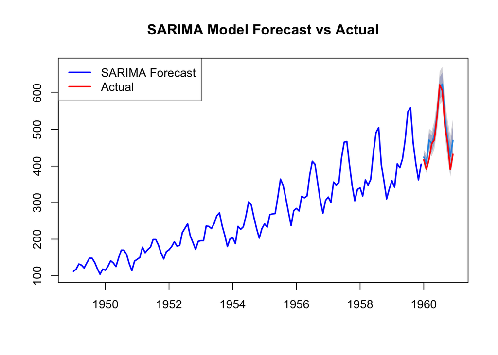

```r
# 12개월 예측 수행
sarima_forecast <- forecast(sarima_model, h = 12)

# 예측 결과 시각화
plot(sarima_forecast, main = "SARIMA Model Forecast vs Actual", col = "blue", lwd = 2)
lines(test_data, col = "red", lwd = 2)  # 실제값 추가
legend("topleft", legend = c("SARIMA Forecast", "Actual"), col = c("blue", "red"), lwd = 2)
```

ARIMA와 SARIMA를 비교에 사용한 지표  
MAPE(Mean Absolute Percentage Error). • 낮을수록 더 좋은 모델.  
• 일반적으로 MAPE < 10% → 매우 정확함, 10~20% → 양호함.

RMSE (Root Mean Squared Error).  
• 예측값과 실제값의 차이(오차)를 나타내는 지표.  
• 값이 낮을수록 예측이 정확함

| 지표 | ARIMA | SARIMA |
| --- | --- | --- |
| MAPE | 9.647887 % | 4.182395 % |
| RMSE | 53.359 | 23.9317 |

ARIMA 방법론도 다른 AR,MA 방법론에 비해 계절성과 추세를 잘 포착한다. 하지만 시각화로 보나 수치적 지표로 보나 SARIMA가 더 좋은 모델임을 알 수 있다.